# Portfolio Assessment: Performance and selling strategies

2020-12-15

A timely retreat is a victory.

### Our portfolio`

Portfolio

| Ticker | nShares | AP | CP | CV | weight |
| --- | --- | --- | --- | --- | --- |
| MC.PA | 14 | 350.0 | 513.70 | 7191.80 | 0.2057831 |
| PUM.DE | 80 | 55.4 | 83.46 | 6676.80 | 0.1910471 |
| AZO | 5 | 1135.0 | 1151.13 | 5755.65 | 0.1646897 |
| DGV.MI | 165 | 30.5 | 34.40 | 5676.00 | 0.1624106 |
| SPGI | 15 | 350.0 | 323.68 | 4855.20 | 0.1389246 |
| UNA.AS | 100 | 46.0 | 47.93 | 4793.00 | 0.1371449 |

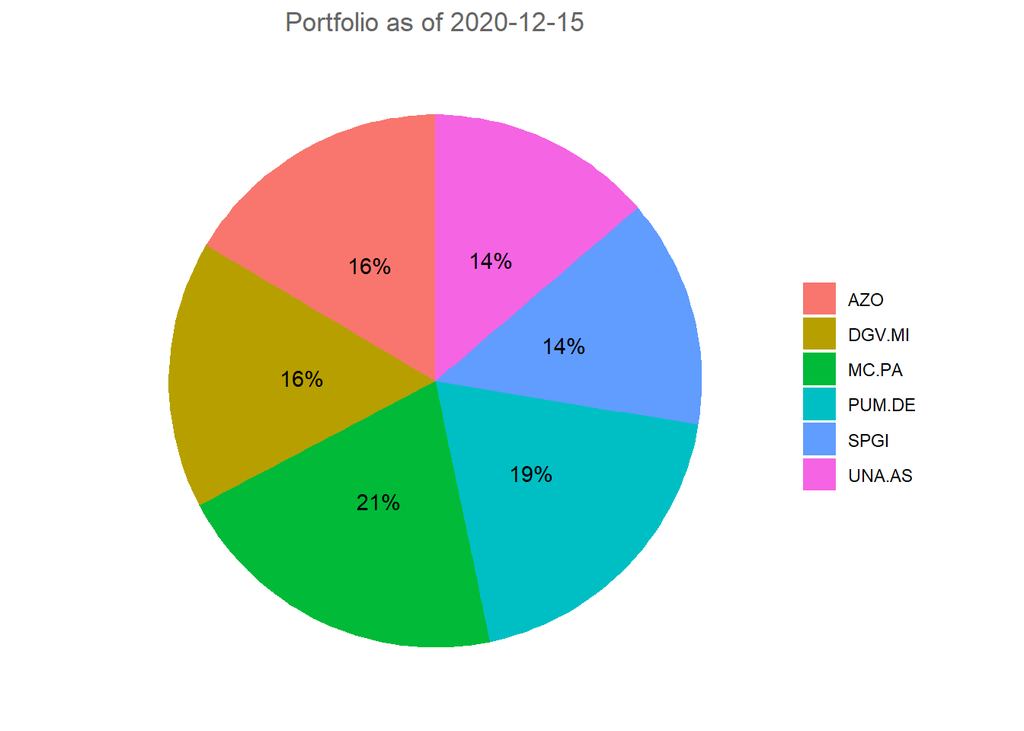

### Factor 1: Quality

1. Healthy debts: A company shoud generate cash in order to repay its debt. The **Free Cash Flow to Debt** ratio is a good indicator of how quick a company pays back its debt. The lower this ratio the better.

FCF2D = $\frac{Debt}{Free Cash Flow}$

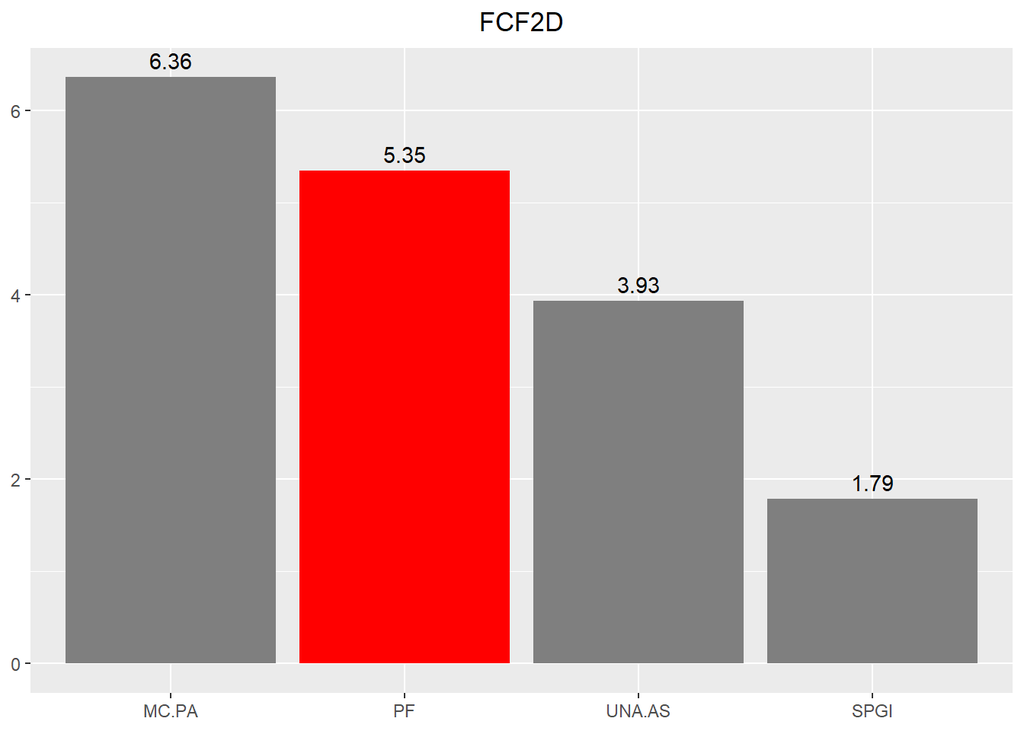

2. Profitability: ROA

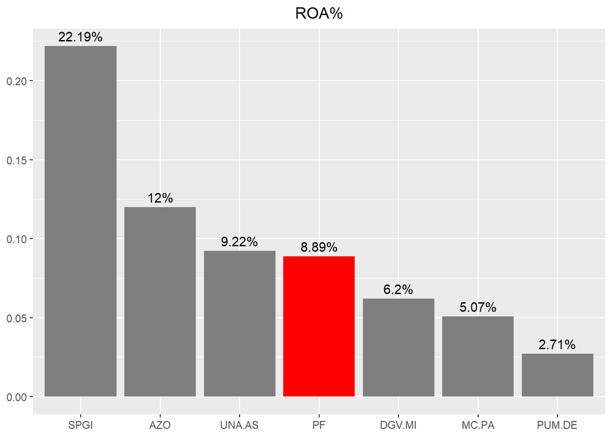

3. High Margin: We look for companies that generate free cash flow compare to its price. The **Free Cash Flow to Entreprise Value** ratio tells us how many years of cash flow would be needed to the return the 100% of the investment. Again, the lower, the better. Values bellow 1 would mean "free lunch".

FCF2EV = $\frac{EV}{Free Cash Flow}$

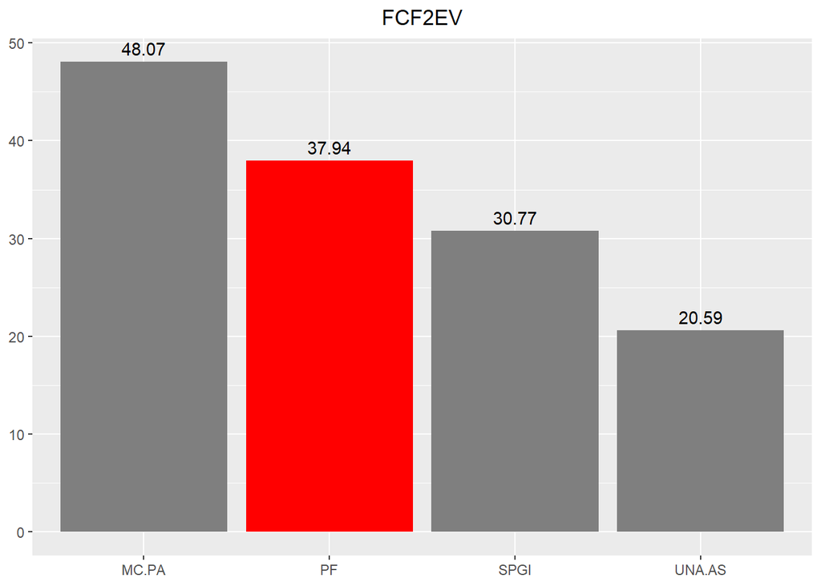

### Factor 2: Momentum

Don't hold onto a stock simply because it is high quality. So called quality stocks have cycles too. Stan Weinstein (page 177)

Generic Intermediate-Term Momentum Based on Gray-Vogel (page 80)

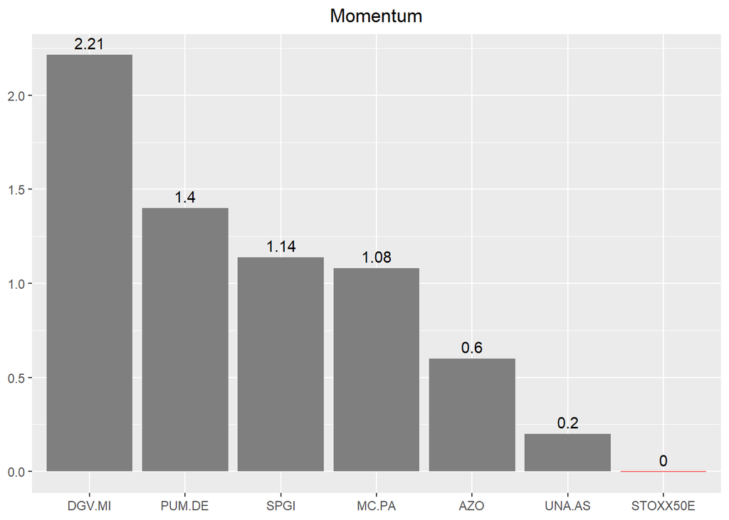

### Factor 3: Timing Signal

Sell Signal - Pr < 1% SMA 30 weeks and slope negative (< 0.1)  
Hold Signal - No Sell

**StopLoss for the next month**

Every month, we calculate a generic the StopLoss given a "Loss Threshold"" of 15% and "ProfitDropThreshold" of 20%. In addition, there's an accurate StopLoss for those stocks with "hold" signal, of 5% of their MA.

### Summary

Summary

| Ticker | AP | CP | weight | StopLoss | Signal | Quality | Momentum | Final_rank |
| --- | --- | --- | --- | --- | --- | --- | --- | --- |
| DGV.MI | 30.5 | 34.40 | 0.1624 | 29.73 | HOLD | 5.0 | 6 | 6 |
| PUM.DE | 55.4 | 83.46 | 0.1910 | 74.10 | HOLD | 3.5 | 5 | 5 |
| AZO | 1135.0 | 1151.13 | 0.1647 | 1103.91 | HOLD | 6.0 | 2 | 4 |
| SPGI | 350.0 | 323.68 | 0.1389 | 326.76 | HOLD | 3.5 | 4 | 3 |
| MC.PA | 350.0 | 513.70 | 0.2058 | 430.49 | HOLD | 1.0 | 3 | 2 |
| UNA.AS | 46.0 | 47.93 | 0.1371 | 47.09 | HOLD | 2.0 | 1 | 1 |